# Lab 7.8.2 & 7.8.3

### Lab 7.8.3 - GAMs

Generalized Additive Model extends a standard linear model by allowing non-linear functions, of each feature while still maintaining additivity. What’s good about GAMs is that it allows both numeric and categorical features.

Install the following packages for this lab:

```r
library(gam)
```

```r
library(akima)
```

We fit a GAM to predict wage using natural spline functions of year and age, treating education as a qualitative predictor. Since this is just a big linear regression model using an appropriate choice of basis functions, we can simply use the lm() function for the gam1 model.

```r
gam1=lm(wage~ns(year,4)+ns(age,5)+education,data=Wage)
```

For gam.m3, we fit the model using smoothing splines rather than natural splines. In order to fit more general sorts of GAMs, using smoothing splines or other components that cannot be expressed in terms of basis functions and then fit using least squares regression, we will need to use the gam library and call the gam() function.

```r
gam.m3=gam(wage~s(year,4)+s(age,5)+education,data=Wage)
```

The s() function, which is part of the gam library, is used to indicate that we would like to use a smoothing spline. We specify that the function of year should have 4 degrees of freedom, and that the function of age will have 5 degrees of freedom. Since education is a qualitative variable, we leave it and it is converted into a dummy variable. The gam() function fits a GAM using these components simultaneously.

The generic plot() function recognizes that gam.m3 is an object of class gam, and invokes plot.Gam() method. Even though gam1 is not of class gam but rather of class lm, we can still use plot.Gam() on it.

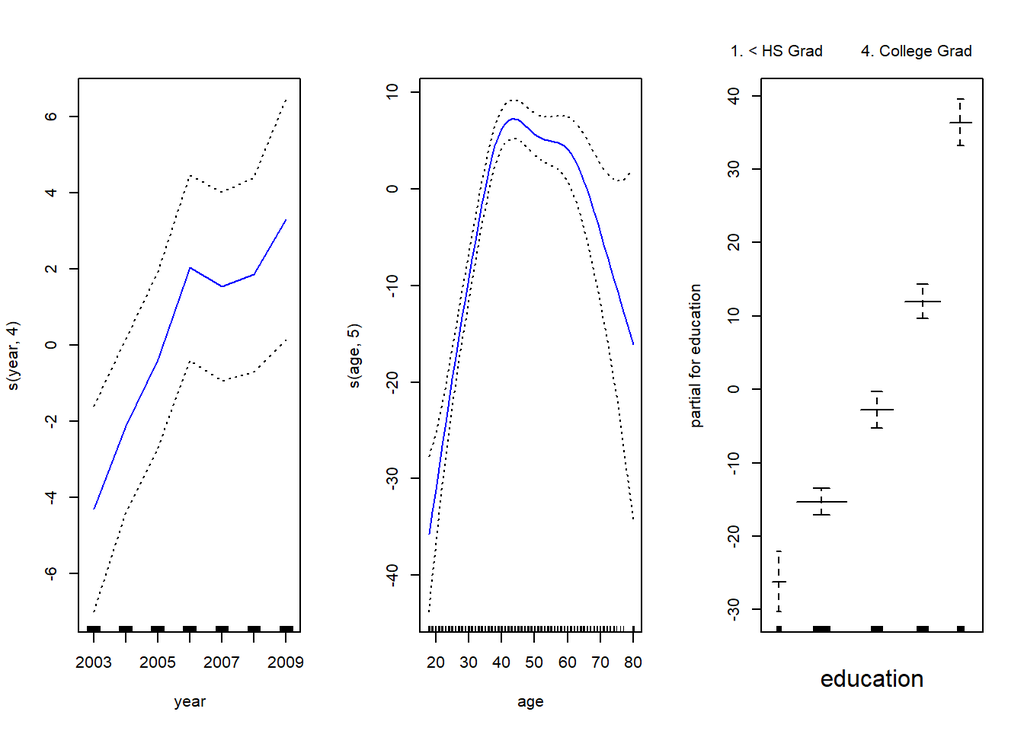

```r
par(mfrow=c(1,3))
plot(gam.m3, se=TRUE,col="blue")
```

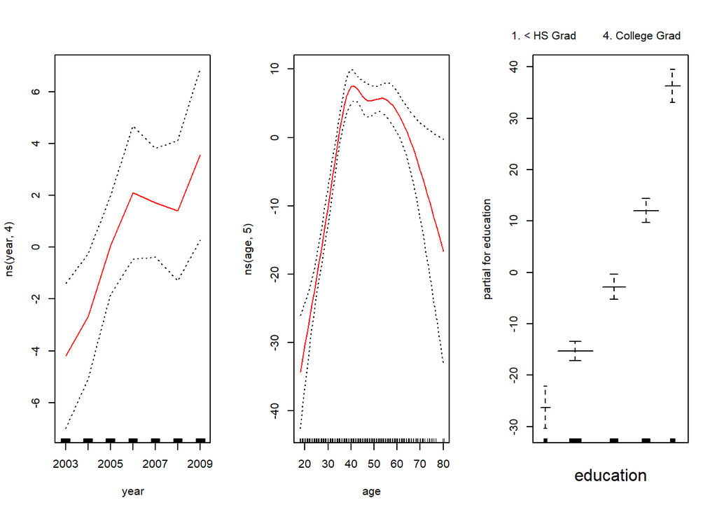

```r
plot.Gam(gam1, se=TRUE, col="red")
```

In these plots, the function year appears linear. We can perform a series of ANOVA tests in order to determine which of these three models is best: a GAM that excludes year (M1), a GAM that uses a linear function of year (M2), or a GAM that uses a spline function of year (M3).

```r
gam.m1=gam(wage~s(age,5)+education,data=Wage)
gam.m2=gam(wage~year+s(age,5)+education,data=Wage)
anova(gam.m1,gam.m2,gam.m3,test="F")
```

```
## Analysis of Deviance Table
##
## Model 1: wage ~ s(age, 5) + education
## Model 2: wage ~ year + s(age, 5) + education
## Model 3: wage ~ s(year, 4) + s(age, 5) + education
##   Resid. Df Resid. Dev Df Deviance       F    Pr(>F)
## 1      2990    3711731
## 2      2989    3693842  1  17889.2 14.4771 0.0001447 ***
## 3      2986    3689770  3   4071.1  1.0982 0.3485661
## ---
## Signif. codes:  0 '***' 0.001 '**' 0.01 '*' 0.05 '.' 0.1 ' ' 1
```

We find that there is compelling evidence that a GAM with a linear function of year is better than a GAM that does not include year at all (note the p-value of 0.0001447). However, there is no evidence that a non-linear function of year is needed (p-value of 0.349). Therefore, we choose M2.

The summary() function produces a summary of the gam fit.

```r
summary(gam.m3)
```

```
##
## Call: gam(formula = wage ~ s(year, 4) + s(age, 5) + education, data = Wage)
## Deviance Residuals:
##     Min      1Q  Median      3Q     Max
## -119.43  -19.70   -3.33   14.17  213.48
##
## (Dispersion Parameter for gaussian family taken to be 1235.69)
##
##     Null Deviance: 5222086 on 2999 degrees of freedom
## Residual Deviance: 3689770 on 2986 degrees of freedom
## AIC: 29887.75
##
## Number of Local Scoring Iterations: 2
##
## Anova for Parametric Effects
##              Df  Sum Sq Mean Sq F value    Pr(>F)
## s(year, 4)    1   27162   27162  21.981 2.877e-06 ***
## s(age, 5)     1  195338  195338 158.081 < 2.2e-16 ***
## education     4 1069726  267432 216.423 < 2.2e-16 ***
## Residuals  2986 3689770    1236
## ---
## Signif. codes:  0 '***' 0.001 '**' 0.01 '*' 0.05 '.' 0.1 ' ' 1
##
## Anova for Nonparametric Effects
##             Npar Df Npar F  Pr(F)
## (Intercept)
## s(year, 4)        3  1.086 0.3537
## s(age, 5)         4 32.380 <2e-16 ***
## education
## ---
## Signif. codes:  0 '***' 0.001 '**' 0.01 '*' 0.05 '.' 0.1 ' ' 1
```

The large p-value of year found in the summary reinforces our conclusion from the ANOVA test that a linear function is adequate for this term. However, there is clear evidence that a non-linear term is required for age.

We can make predictions from gam objects, just like from lm objects, using the predict() method for the class gam. Below we make predictions on the training set.

```r
preds=predict(gam.m2,newdata=Wage)
```

We can also use local regression fits as building blocks in a GAM, using the lo() function.

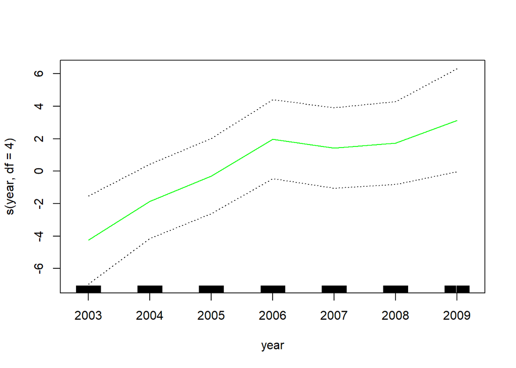

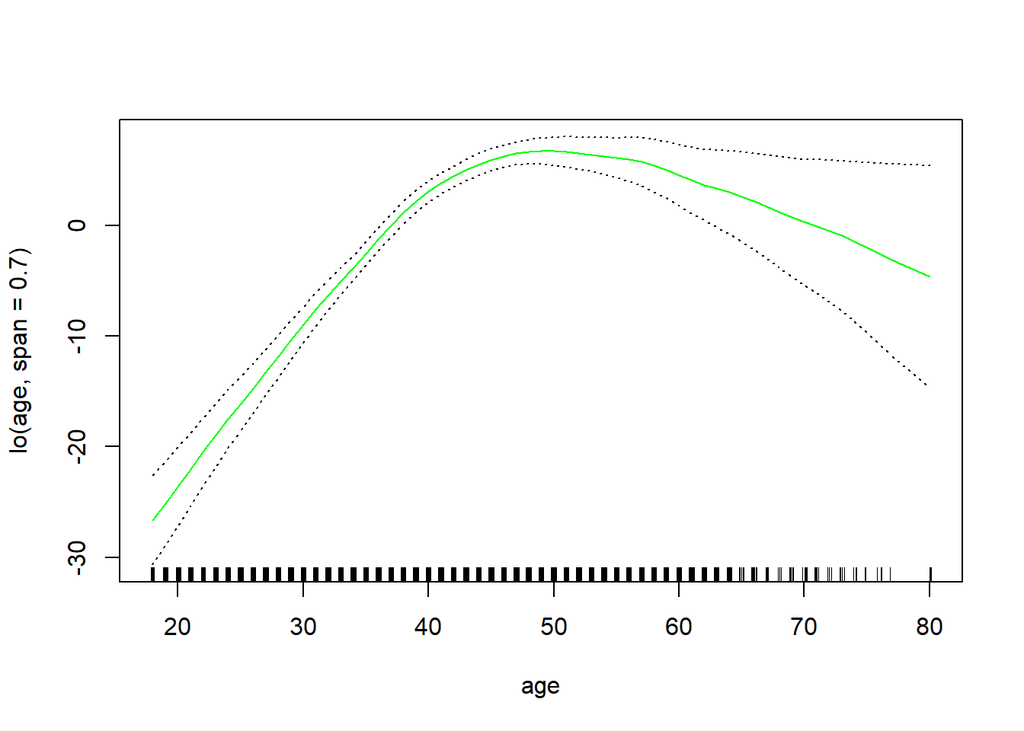

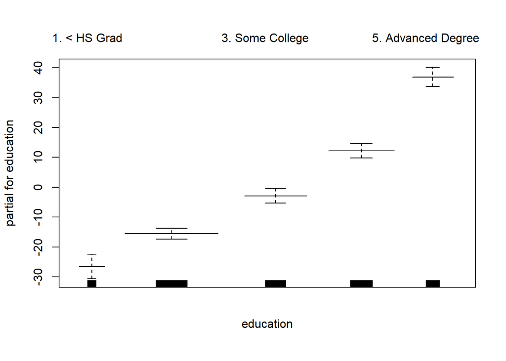

```r
gam.lo=gam(wage~s(year,df=4)+lo(age,span=0.7)+education,data=Wage)
plot.Gam(gam.lo, se=TRUE, col="green")
```

Here we have used local regression for the age term, with a span of 0.7.